# クラスタリング

更新：2026-06-23

## 分析例①：階層的クラスタリング

### データ

**品目別1世帯当たり年間支出金額（都道府県庁所在地）**

| 都市 | 穀類 | 魚介類 | 肉類 | 乳卵類 | 野菜・海藻 | 果物 | 油脂・調味料 | 菓子類 | 調理食品 | 飲料 | 酒類 | 外食 |
| --- | --- | --- | --- | --- | --- | --- | --- | --- | --- | --- | --- | --- |
| 札幌市 | 79181 | 76770 | 93791 | 47779 | 102788 | 36503 | 44390 | 95309 | 116139 | 59318 | 47235 | 149922 |
| 青森市 | 78915 | 91141 | 96815 | 47182 | 113969 | 41643 | 45972 | 92818 | 138972 | 72945 | 64525 | 103102 |
| 盛岡市 | 81255 | 76782 | 84422 | 51870 | 114664 | 43718 | 49495 | 111263 | 144761 | 76551 | 61170 | 142705 |
| 仙台市 | 82649 | 76030 | 95781 | 52899 | 118537 | 44601 | 47804 | 107931 | 150850 | 70359 | 50569 | 159754 |
| 秋田市 | 72734 | 82837 | 92338 | 50291 | 126828 | 45722 | 49685 | 93845 | 133264 | 66546 | 57363 | 126871 |
| 山形市 | 81066 | 78362 | 107347 | 56187 | 119891 | 56630 | 49835 | 108455 | 147330 | 64945 | 55449 | 163930 |

**データ出典** ：[総務省 家計調査（家計収支編 都市階級・地方・都道府県庁所在市別１世帯当たり支出金額，購入数量及び平均価格）](https://www.e-stat.go.jp/stat-search/files?page=1&stat_infid=000040140558)

### Rコード

```r
# データの読込
kakei2023 <- read.csv("data/kakei2023.csv", row.names = 1)  # row.names = 1 で1列目（都市名）を行名に指定

# 各列の標準化
kakei2023s <- scale(kakei2023)
head(kakei2023s)

# 都道府県間の類似度（距離行列）の計算
dist <- dist(kakei2023s)

# 階層的クラスタリング
hc <- hclust(d = dist, method = "ward.D2")
plot(hc)
```

**`scale(x)`**：データの標準化

- **`x`**：データ
- `scale` 関数は列単位でデータを標準化（平均0・標準偏差1に変換）

**`dist(x)`**：サンプル間の距離行列の計算

- **`x`**：データ
- デフォルトではユークリッド距離が計算される

**`hclust(d, method)`**：階層的クラスタリングの実行

- **`d`**：距離行列
- **`method`**：クラスタリングの方法の指定（`ward.D2` は Ward 法）

##### Rコードの出力

標準化後のデータ

```
##              穀類    魚介類        肉類     乳卵類  野菜.海藻        果物
## 札幌市 -0.1105125 0.5806367 -0.37519106 -0.8033045 -0.3741955 -0.81512891
## 青森市 -0.1590946 2.4272402 -0.05989827 -0.9504770  0.6058360  0.06008539
## 盛岡市  0.2682819 0.5821786 -1.35203569  0.2052097  0.6667538  0.41340634
## 仙台市  0.5228814 0.4855503 -0.16770671  0.4588790  1.0062281  0.56375931
## 秋田市 -1.2879894 1.3602166 -0.52668591 -0.1840457  1.7329467  0.75463776
## 山形市  0.2337630 0.7852009  1.03820480  1.2694375  1.1249082  2.61199916
##        油脂.調味料     菓子類   調理食品        飲料      酒類       外食
## 札幌市  -0.9785878 -0.5754339 -2.3546524 -0.92299225 0.2112131 -0.6815903
## 青森市  -0.4174390 -0.8932368 -0.7562778  1.52002014 2.4367240 -2.1457607
## 盛岡市   0.8321989  1.4599843 -0.3510314  2.16649425 2.0048796 -0.9072827
## 仙台市   0.2323869  1.0348863  0.0752158  1.05640892 0.6403544 -0.3741208
## 秋田市   0.8995935 -0.7622117 -1.1558539  0.37282441 1.5148553 -1.4024488
## 山形市   0.9527998  1.1017385 -0.1711941  0.08580137 1.2684917 -0.2435276
```

階層的クラスタリング（デンドログラム）

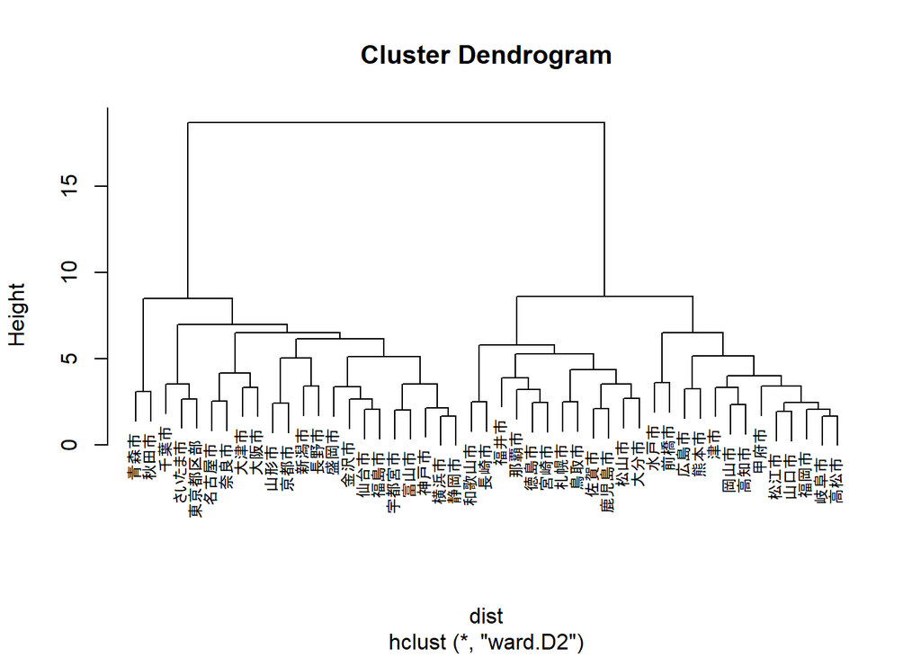

## 分析例②：非階層的クラスタリング（K-means 法）

### データ

品目別1世帯当たり年間支出金額（都道府県庁所在地） ⇒ 分析例①と同一データ

### Rコード

```r
# 乱数シードの固定（初期値の違いによる分析結果のゆれをなくすための設定）
set.seed(1)

# クラスター分析（kmens法，クラスター数＝4）
result <- kmeans(x = kakei2023s, centers = 4)

# 各セグメントの標準化支出金額の平均値（代表値） & 各都市の所属セグメント番号
print(result)

# print(sort(result$cluster)) # 参考：所属セグメント番号による都市のソート


# 各セグメントの所属都市数・比率
print(result$size)
print(result$size/47)   # 比率

# （参考）各セグメントの代表値の図示
for (i in 1:4) {
  barplot(result$centers[i,], ylim = c(-1.3, 1.3), las = 2, main = paste("セグメント", i))
}
```

**`kmeans(x, centers)`**：Kmeans法によるクラスター分析

- **`x`**：クラスター分析を実行するデータの指定
- **`centers`**：セグメント数

##### Rコードの出力

各セグメントの標準化支出金額の平均値（代表値）

```
##         穀類     魚介類       肉類     乳卵類  野菜.海藻       果物 油脂.調味料
## 1  0.7896721  0.6154508  0.5174347  0.7578464  0.6764776  0.4074041   0.5386555
## 2 -0.6720742 -0.7982574 -0.8889703 -0.3349654 -0.6849726 -0.1557213  -0.9961814
## 3 -0.6167049 -0.6085857  0.4481296 -0.8907433 -0.8982099 -0.9571384  -0.4283804
## 4  0.2628940  0.7558719 -0.6518673  0.3504718  0.9628516  0.9351933   0.8640340
##       菓子類   調理食品       飲料        酒類       外食
## 1  0.6897414  0.9541757  0.2766533  0.02274776  0.9527112
## 2 -0.3540053 -0.1056925  0.1241667 -0.82428666 -0.0947620
## 3 -0.7511024 -0.9048399 -0.8131228 -0.19828411 -0.5571072
## 4  0.2835652 -0.3058708  0.6128095  1.30707448 -0.8816707
```

各都市の所属セグメント番号

```
##     札幌市     青森市     盛岡市     仙台市     秋田市     山形市     福島市
##          3          4          4          4          4          4          4
##     水戸市   宇都宮市     前橋市 さいたま市     千葉市 東京都区部     横浜市
##          2          1          2          1          1          1          1
##     新潟市     富山市     金沢市     福井市     甲府市     長野市     岐阜市
##          4          1          1          2          2          4          2
##     静岡市   名古屋市       津市     大津市     京都市     大阪市     神戸市
##          1          1          1          1          1          1          1
##     奈良市   和歌山市     鳥取市     松江市     岡山市     広島市     山口市
##          1          3          3          3          2          1          3
##     徳島市     高松市     松山市     高知市     福岡市     佐賀市     長崎市
##          2          2          3          2          3          3          3
##     熊本市     大分市     宮崎市   鹿児島市     那覇市
##          3          3          3          3          2
```

[output not shown]

各セグメントの所属都市数・比率

```
## [1] 16 10 13  8
## [1] 0.3404255 0.2127660 0.2765957 0.1702128
```

各セグメントの代表値の図示

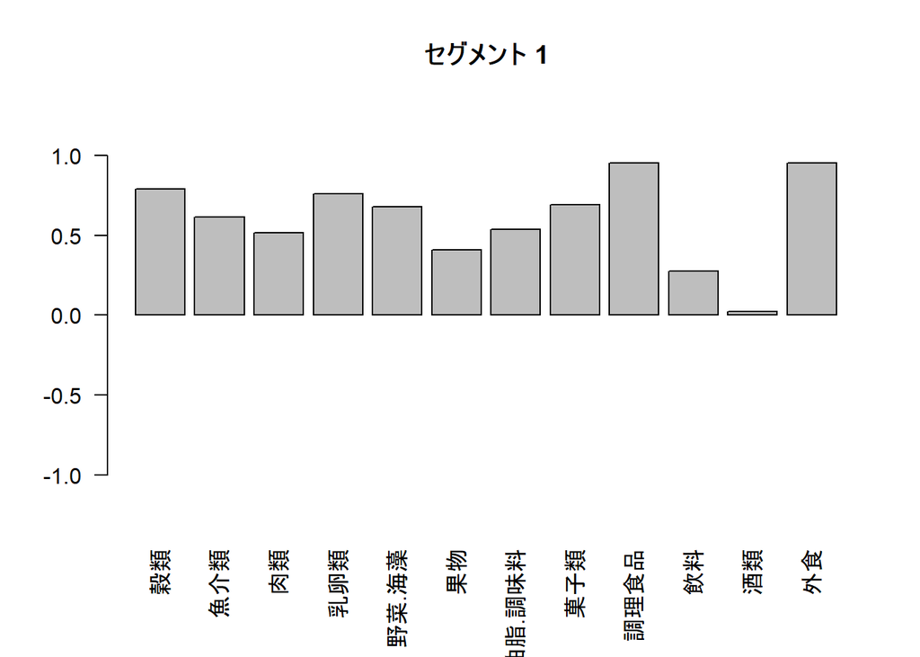

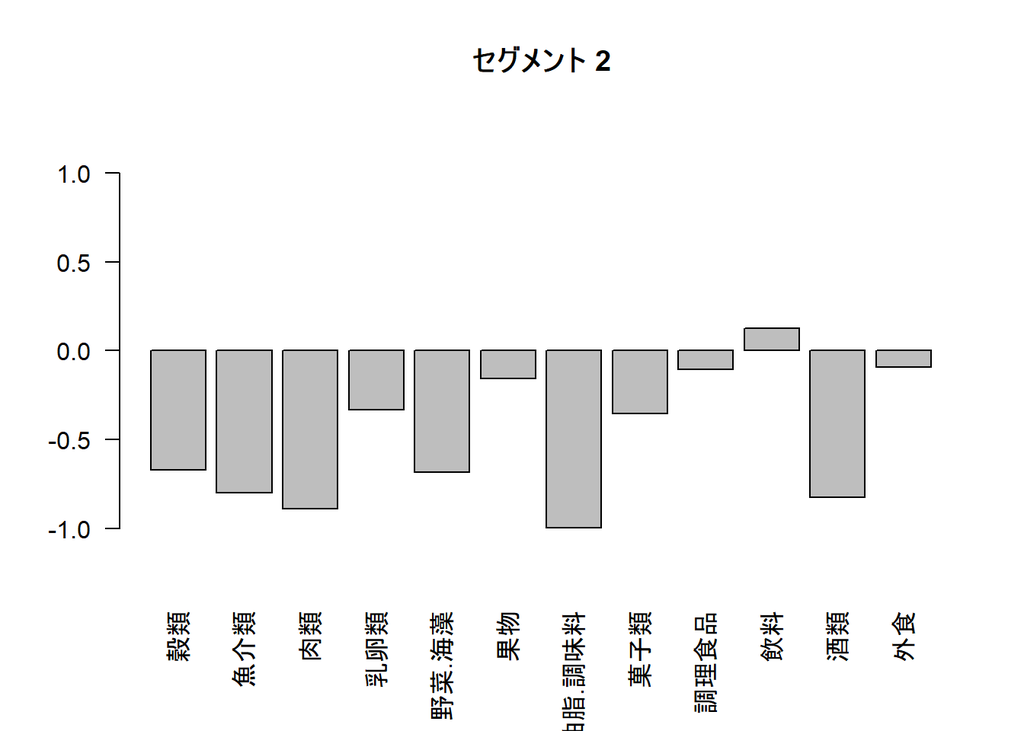

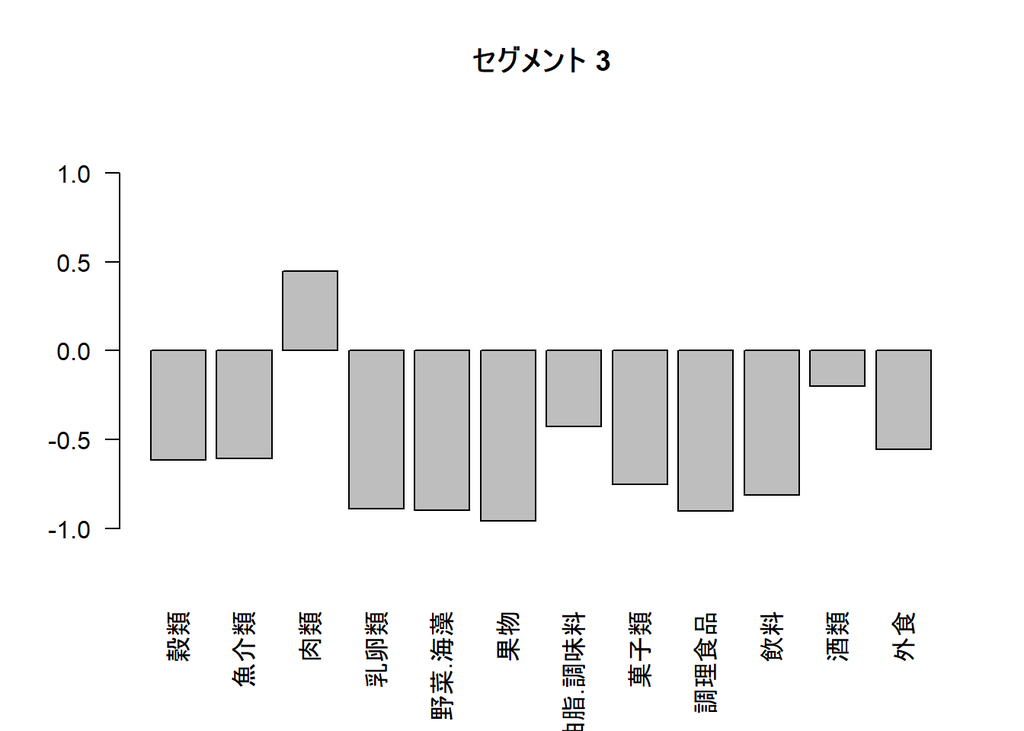

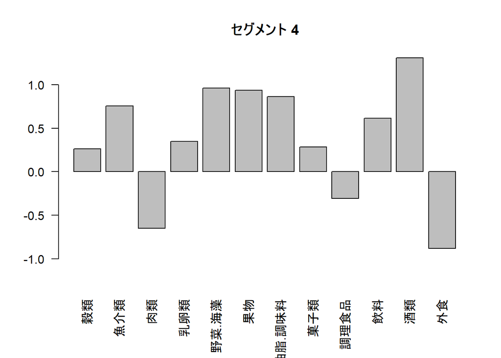

## 分析例③：潜在クラスモデル*

### データ

**醤油カテゴリのID付POSデータ**（sec6_mixture.csv）

| pid | A | B | C | D | E | F | G | H | I | ALL | Ap | Bp | Cp | Dp | Ep | Fp | Gp | Hp | Ip | Ae | Be | Ce | De | Ee | Fe | Ge | He | Ie | Aa | … |
| --- | --- | --- | --- | --- | --- | --- | --- | --- | --- | --- | --- | --- | --- | --- | --- | --- | --- | --- | --- | --- | --- | --- | --- | --- | --- | --- | --- | --- | --- | --- |
| 100011 | 0 | 0 | 2 | 0 | 0 | 0 | 0 | 0 | 0 | 2 | 0.9979730 | 0.7780374 | 0.7309168 | 0.8776869 | 0.8360656 | 0.5986348 | 1.0000000 | 0.8198440 | 0.8481308 | 0 | 1 | 1 | 1 | 0 | 2 | 0 | 1 | 1 | 0 | … |
| 100075 | 0 | 0 | 2 | 0 | 0 | 0 | 0 | 0 | 0 | 2 | 1.0000000 | 1.0000000 | 0.5739437 | 0.9415888 | 0.9487705 | 0.7269625 | 0.9401914 | 0.9402730 | 0.9415888 | 1 | 0 | 2 | 0 | 0 | 1 | 0 | 0 | 0 | 0 | … |
| 100149 | 0 | 0 | 3 | 0 | 0 | 0 | 0 | 0 | 0 | 3 | 1.0000000 | 0.8948598 | 0.4987095 | 0.9579439 | 1.0000000 | 0.8350398 | 0.9202552 | 0.9374289 | 0.9610592 | 1 | 1 | 2 | 0 | 0 | 1 | 0 | 1 | 0 | 0 | … |
| 100301 | 0 | 1 | 2 | 0 | 0 | 0 | 0 | 0 | 0 | 3 | 0.9997820 | 0.8598131 | 0.7158431 | 0.8598131 | 0.9658470 | 0.8152121 | 0.9601276 | 0.9203640 | 0.8598131 | 0 | 1 | 1 | 1 | 0 | 0 | 0 | 0 | 0 | 0 | … |
| 100303 | 0 | 0 | 1 | 0 | 0 | 0 | 0 | 1 | 0 | 2 | 0.9876422 | 0.8769470 | 0.6846635 | 0.9778037 | 1.0000000 | 0.8583618 | 0.8122010 | 0.7568773 | 0.9304907 | 1 | 0 | 1 | 0 | 0 | 1 | 0 | 1 | 0 | 0 | … |
| 100406 | 0 | 0 | 0 | 0 | 0 | 2 | 0 | 0 | 0 | 2 | 1.0000000 | 0.6962617 | 0.7500000 | 0.7897196 | 0.9165691 | 0.6416382 | 1.0000000 | 0.9402730 | 1.0000000 | 1 | 1 | 0 | 1 | 0 | 1 | 0 | 0 | 0 | 0 | … |

| 変数名 | 内容 |
| --- | --- |
| pid | 消費者ID |
| A ~ I | 商品A～Iの購買回数 |
| **ALL** | **観測期間における全商品（A～I）の購買回数** |
| **Ap ~ Ip** | **商品A～Iの購買時の平均価格掛率** |
| Ae ~ Ie | 商品A～Iの購買時の山積み陳列実施数 |
| Aa ~ Ia | 商品A～Iの購買時のチラシ掲載日数 |

（太字は以下の分析例で使用する変数。ただし商品AはPBで価格変動が少ないためApは利用しない。）

**データ出典** ：佐藤（2015）「マーケティングの統計モデル」朝倉書店，第6章

### Rコード

#### 通常のポアソン回帰

```r
# データの読み込み
sec6_mixture <- read.csv("data/sec6_mixture.csv")

# ポアソン回帰の実行
result_glm <- glm(
  ALL ~ log(Bp) + log(Cp) + log(Dp) + log(Ep) + log(Fp) + log(Gp) + log(Hp) + log(Ip),
  family = "poisson",
  data = sec6_mixture
)

# 結果の表示
summary(result_glm)
```

**`glm(formula, family, data)` ：ポアソン回帰の推定**

- **`formula`**：目的変数・説明変数の指定
- **`family`**：分析モデル（データが従う確率分布）の指定 ⇒ ポアソン回帰の場合は `"poisson"` を指定
- **`data`**：分析データの指定

##### Rコードの出力

```
##
## Call:
## glm(formula = ALL ~ log(Bp) + log(Cp) + log(Dp) + log(Ep) + log(Fp) +
##     log(Gp) + log(Hp) + log(Ip), family = "poisson", data = sec6_mixture)
##
## Coefficients:
##              Estimate Std. Error z value Pr(>|z|)
## (Intercept)  2.635905   0.061802  42.651  < 2e-16 ***
## log(Bp)      1.463823   0.281309   5.204 1.95e-07 ***
## log(Cp)      1.832826   0.153734  11.922  < 2e-16 ***
## log(Dp)     -0.650710   0.300137  -2.168   0.0302 *
## log(Ep)     -2.050010   0.408935  -5.013 5.36e-07 ***
## log(Fp)      0.006202   0.223738   0.028   0.9779
## log(Gp)      0.295960   0.426631   0.694   0.4879
## log(Hp)     -0.726229   0.120598  -6.022 1.72e-09 ***
## log(Ip)      1.346584   0.339694   3.964 7.37e-05 ***
## ---
## Signif. codes:  0 '***' 0.001 '**' 0.01 '*' 0.05 '.' 0.1 ' ' 1
##
## (Dispersion parameter for poisson family taken to be 1)
##
##     Null deviance: 3534.7  on 309  degrees of freedom
## Residual deviance: 3001.0  on 301  degrees of freedom
## AIC: 4137.2
##
## Number of Fisher Scoring iterations: 5
```

#### 潜在クラスモデル（有限混合ポアソン回帰）

```r
# flexmix パッケージのインストール（初回のみ実行）
# install.packages("flexmix")

# パッケージの読込み
library(flexmix)

set.seed(1) # 初期値の違いによる分析結果のゆれをなくすための設定

# セグメント数1～5の潜在クラスポアソン回帰の一括実行
result_mixture <- initFlexmix(
  ALL ~ log(Bp) + log(Cp) + log(Dp) + log(Ep) + log(Fp) + log(Gp) + log(Hp) + log(Ip),
  k = 1:5,
  model = FLXMRglm(family = "poisson"),
  data = sec6_mixture
)

# モデル比較（最適セグメント数の決定）
print(result_mixture)

# 最良モデルの選択（BIC基準）
best_model <- getModel(result_mixture, which = "BIC")

# 最良モデルのセグメント構成比
summary(best_model)

# 各セグメントの係数推定値
summary(refit(best_model))
```

**`initFlexmix(formula, k, model, data)` ：潜在クラスモデルの推定**

- **`formula`**：目的変数・説明変数の指定
- **`k`**：推定するセグメント数 ⇒ `k = 1:5` でセグメント数1〜5のモデルを一括で実行可能
- **`model`**：分析モデルの指定 ⇒ ポアソン回帰の場合は `FLXMRglm(family = "poisson")`，線形回帰分析の場合は不要
- **`data`**：分析データの指定

##### Rコードの出力

モデル比較

```
##
## Call:
## initFlexmix(ALL ~ log(Bp) + log(Cp) + log(Dp) + log(Ep) + log(Fp) +
##     log(Gp) + log(Hp) + log(Ip), model = FLXMRglm(family = "poisson"),
##     data = sec6_mixture, k = 1:5)
##
##   iter converged k k0     logLik      AIC      BIC      ICL
## 1    2      TRUE 1  1 -2059.6215 4137.243 4170.872 4170.872
## 2   10      TRUE 2  2 -1087.1315 2212.263 2283.258 2327.518
## 3   48      TRUE 3  3 -1012.9326 2083.865 2192.226 2311.004
## 4   92      TRUE 4  4  -964.0726 2006.145 2151.871 2410.577
## 5   64      TRUE 5  5  -947.9512 1993.902 2176.995 2513.820
```

最良モデル (k=4) のセグメント構成比（pior列）

```
##
## Call:
## initFlexmix(ALL ~ log(Bp) + log(Cp) + log(Dp) + log(Ep) + log(Fp) +
##     log(Gp) + log(Hp) + log(Ip), model = FLXMRglm(family = "poisson"),
##     data = sec6_mixture, k = 4)
##
##        prior size post>0 ratio
## Comp.1 0.283  102    207 0.493
## Comp.2 0.262   81    235 0.345
## Comp.3 0.275   82    236 0.347
## Comp.4 0.180   45    171 0.263
##
## 'log Lik.' -964.0726 (df=39)
## AIC: 2006.145   BIC: 2151.871
```

各セグメントの係数推定値

```
## $Comp.1
##               Estimate Std. Error z value  Pr(>|z|)
## (Intercept)  1.0525304  0.2373745  4.4341 9.248e-06 ***
## log(Bp)      0.6872932  0.9201333  0.7469    0.4551
## log(Cp)     -0.0163635  0.4868642 -0.0336    0.9732
## log(Dp)      0.0776816  1.0969446  0.0708    0.9435
## log(Ep)     -0.3740525  1.4737193 -0.2538    0.7996
## log(Fp)      0.1876122  0.7589703  0.2472    0.8048
## log(Gp)      0.1539687  1.4752182  0.1044    0.9169
## log(Hp)      0.0014165  0.4800496  0.0030    0.9976
## log(Ip)      0.5249260  1.0256108  0.5118    0.6088
## ---
## Signif. codes:  0 '***' 0.001 '**' 0.01 '*' 0.05 '.' 0.1 ' ' 1
##
## $Comp.2
##              Estimate Std. Error z value  Pr(>|z|)
## (Intercept)   2.28267    0.35597  6.4126 1.431e-10 ***
## log(Bp)       4.12479    1.32441  3.1144 0.0018430 **
## log(Cp)       0.33644    0.52869  0.6364 0.5245412
## log(Dp)       0.16015    1.37682  0.1163 0.9074022
## log(Ep)     -10.09257    2.02229 -4.9907 6.017e-07 ***
## log(Fp)       0.83517    1.20726  0.6918 0.4890693
## log(Gp)       5.68026    2.17518  2.6114 0.0090174 **
## log(Hp)       0.34703    0.49723  0.6979 0.4852216
## log(Ip)      -6.03184    1.77126 -3.4054 0.0006607 ***
## ---
## Signif. codes:  0 '***' 0.001 '**' 0.01 '*' 0.05 '.' 0.1 ' ' 1
##
## $Comp.3
##             Estimate Std. Error z value  Pr(>|z|)
## (Intercept)  0.94903    0.39688  2.3912 0.0167937 *
## log(Bp)     -1.27373    1.39459 -0.9133 0.3610667
## log(Cp)      1.66738    0.61296  2.7202 0.0065246 **
## log(Dp)     -3.14500    1.31079 -2.3993 0.0164257 *
## log(Ep)     -8.80006    2.20874 -3.9842 6.771e-05 ***
## log(Fp)      2.82726    1.19640  2.3631 0.0181209 *
## log(Gp)     -6.86588    2.08446 -3.2939 0.0009883 ***
## log(Hp)     -4.36897    0.48548 -8.9992 < 2.2e-16 ***
## log(Ip)      5.59482    1.91465  2.9221 0.0034768 **
## ---
## Signif. codes:  0 '***' 0.001 '**' 0.01 '*' 0.05 '.' 0.1 ' ' 1
##
## $Comp.4
##             Estimate Std. Error z value  Pr(>|z|)
## (Intercept)  4.17800    0.28499 14.6601 < 2.2e-16 ***
## log(Bp)      3.64307    1.50516  2.4204 0.0155038 *
## log(Cp)      6.97370    0.76265  9.1441 < 2.2e-16 ***
## log(Dp)     -1.38228    1.35658 -1.0189 0.3082319
## log(Ep)      2.33638    2.00605  1.1647 0.2441539
## log(Fp)     -3.33686    1.48825 -2.2421 0.0249527 *
## log(Gp)      3.17050    2.93194  1.0814 0.2795346
## log(Hp)     -1.42323    0.41581 -3.4228 0.0006199 ***
## log(Ip)     -0.28842    2.46528 -0.1170 0.9068662
## ---
## Signif. codes:  0 '***' 0.001 '**' 0.01 '*' 0.05 '.' 0.1 ' ' 1
```

### 推定結果

|  | セグメント1 Estimate | セグメント1 p.val | セグメント2 Estimate | セグメント2 p.val | セグメント3 Estimate | セグメント3 p.val | セグメント4 Estimate | セグメント4 p.val | （参考：ポアソン回帰） Estimate | （参考：ポアソン回帰） p.val |
| --- | --- | --- | --- | --- | --- | --- | --- | --- | --- | --- |
| (Intercept) | 1.053 | 0.000 | 2.283 | 0.000 | 0.949 | 0.017 | 4.178 | 0.000 | 2.636 | 0.000 |
| log(Bp) | 0.687 | 0.455 | 4.125 | 0.002 | -1.274 | 0.361 | 3.643 | 0.016 | 1.464 | 0.000 |
| log(Cp) | -0.016 | 0.973 | 0.336 | 0.525 | 1.667 | 0.007 | 6.974 | 0.000 | 1.833 | 0.000 |
| log(Dp) | 0.078 | 0.944 | 0.160 | 0.907 | -3.145 | 0.016 | -1.382 | 0.308 | -0.651 | 0.030 |
| log(Ep) | -0.374 | 0.800 | -10.093 | 0.000 | -8.800 | 0.000 | 2.336 | 0.244 | -2.050 | 0.000 |
| log(Fp) | 0.188 | 0.805 | 0.835 | 0.489 | 2.827 | 0.018 | -3.337 | 0.025 | 0.006 | 0.978 |
| log(Gp) | 0.154 | 0.917 | 5.680 | 0.009 | -6.866 | 0.001 | 3.171 | 0.280 | 0.296 | 0.488 |
| log(Hp) | 0.001 | 0.998 | 0.347 | 0.485 | -4.369 | 0.000 | -1.423 | 0.001 | -0.726 | 0.000 |
| log(Ip) | 0.525 | 0.609 | -6.032 | 0.001 | 5.595 | 0.003 | -0.288 | 0.907 | 1.347 | 0.000 |

- 消費者の28％を占めるセグメント1は全ての製品の価格が非有意 ⇒ 家庭内在庫がなくなれば購入する消費者？
- セグメント2は商品E・Iが値引きされていると購買しやすい
- セグメント3は商品D・E・G・Hが値引きされていると購買しやすい